# Pairs Trading: A Stochastic Mean–Variance Approach

In this project, I consider optimal pairs trading strategies in terms of static optimality and dynamic optimality under mean–variance criterion. The spread of the entity pairs is assumed to be **mean-reverting and follows an Ornstein–Uhlenbeck process**. A constrained optimal control problem is considered, and the Lagrange multiplier technique is adopted to transform the primal problem into a family of **linear-quadratic optimal control problems** that can be solved by the classical dynamic programming principle. Both solutions for static and dynamic optimal pairs trading problems are derived and discussed.

## The model dynamics

Assume that a risk-free asset $N(t)$ exists with a risk-free rate of $r$ compounded continuously. Thus, $N(t)$ satisfies the dynamics

$$ dN(t) = r N(t) dt \quad (1) $$

Let $A(t)$ and $B(t)$ denote, respectively, the prices of stocks A and B at time $t$. We assume that stock B follows a **geometric Brownian motion**.

$$ \frac{dB(t)}{B(t)} = μdt + σdZ(t), \quad (2) $$

where constants $μ$ and $σ$ are the drift and the volatility, respectively. Here, $Z(t)$ is a standard Brownian motion. Let $γ$ be a predetermined ratio and $X(t)$ denote the spread of stocks A and B at time $t$, defined as

$$ X(t) = \ln(A(t)) - γ \ln(B(t)). \quad (3) $$

We further assume that the spread follows an **Ornstein–Uhlenbeck process**

$$ dX(t) = k(θ - X(t))dt + ηdW(t), \quad X(t_0) = x_0, \quad (4) $$

where $W(t)$ is a standard Brownian motion, and $ρ$ denotes the instantaneous correlation coefficient between $Z(t)$ and $W(t)$. Therefore, by a straightforward calculation, we obtain

$$ \frac{dA(t)}{A(t)} = \left[k(θ - X(t)) + γ μ + \frac{η^2}{2} + \frac{σ^2γ(γ - 1)}{2} + ρσ ηγ\right]dt + σdZ(t) + ηdW(t). \quad (5) $$

Let $V(t)$ be the value of a self-financing pairs-trading portfolio, $h(t)$ and $1 - (1 - γ)h(t)$ denote the portfolio weights of the stock pair and the risk-free asset at time $t$, respectively. Then, the wealth process $V(t)$ becomes

$$ \begin{align*} dV(t) & = V(t) \left[h(t) \frac{dA(t)}{A(t)} - h(t)γ \frac{dB(t)}{B(t)} + \left[1 - (1 - γ)h(t)\right] \frac{dN(t)}{N(t)}\right], \quad (6) \end{align*} $$

Substituting Eqs. (2) and (5) into Eq. (6), we have

$$ \begin{align*} dV(t) & = V(t) \left[\left[r + (κ - kX(t))h(t)\right]dt + ηh(t)dW(t)\right], \quad V(t_0) = v_0, \quad (7) \end{align*} $$

where

$$ κ = kθ + \frac{σ^2γ(γ - 1)}{2} + \frac{η^2}{2} + ρσ ηγ - (1 - γ)r. \quad (8) $$

If we further consider more general dynamics of stock B, for instance, we consider a geometric Lévy process to include jumps, then the dynamics of B can be written as

$$ \frac{dB(t)}{B(t^-)} = \mu dt + \sigma dZ(t) + d\left(\sum_{i=1}^{K(t)} \left(e^{\xi_i} - 1\right)\right), \quad (9) $$

where $K(t)$ is a Poisson process with intensity $\nu$, and $\xi_i$ for $i = 1, 2, \ldots$ are random variables that model the sizes of jumps. Note that I assume the sizes to be $e^{\xi_i} - 1 > -1$ in order to ensure that $B(t) > 0$.

Setting the coefficient of $x^2$ in (21) to be zero yields an ordinary differential equation for $\alpha(t)$ $$[(\gamma - 1)\eta^2]\alpha'4\alpha^2 + [2k\eta^2]\alpha + [-\frac{1}{2}\gamma k^2] = 0.$$ (22)

Similarly, setting the coefficient of $x$ in (21) to be zero yields an ordinary differential equation for $\beta(t)$ $$[(\gamma - 1)\eta^2]\beta'2 - 2\eta^4\alpha\beta + [-\gamma\eta^4 - 2\gamma\rho\sigma\eta^3\alpha -2k\theta\eta^2\alpha + \gamma k^2\theta + \frac{1}{2}\gamma k\eta^2 + \gamma k\rho\eta\sigma] = 0.$$ (23)

### Data Engineering

```python
stocks = ['AAPL', 'MSFT', 'GS', 'JPM', 'GOOGL', 'AMZN', 'TSLA', 'FB', 'NFLX', 'IBM', 'INTC', 'CSCO', 'ORCL', 'QCOM', 'WMT', 'VZ', 'KO', 'PEP', 'MCD', 'NKE']
start, end, interval = '2017-12-14', '2023-12-20', '1d'
data = {}
for symbol in stocks:
    data[symbol] = yf.download(symbol, start=start, end=end, interval=interval, progress=False)
```

```
1 Failed download:
['FB']: Exception('%ticker%: No timezone found, symbol may be delisted')
```

```python
data['AAPL']
```

| Date | Open | High | Low | Close | Adj Close | Volume |
| --- | --- | --- | --- | --- | --- | --- |
| 2017-12-14 | 43.099998 | 43.282501 | 42.912498 | 43.055000 | 41.300484 | 81906000 |
| 2017-12-15 | 43.407501 | 43.542500 | 43.115002 | 43.492500 | 41.720161 | 160677200 |
| 2017-12-18 | 43.720001 | 44.299999 | 43.715000 | 44.105000 | 42.307701 | 117684400 |
| 2017-12-19 | 43.757500 | 43.847500 | 43.522499 | 43.634998 | 41.856853 | 109745600 |
| 2017-12-20 | 43.717499 | 43.855000 | 43.312500 | 43.587502 | 41.811283 | 93902400 |
| ... | ... | ... | ... | ... | ... | ... |
| 2023-12-13 | 195.089996 | 198.000000 | 194.850006 | 197.960007 | 197.960007 | 70404200 |
| 2023-12-14 | 198.020004 | 199.619995 | 196.160004 | 198.110001 | 198.110001 | 66831600 |
| 2023-12-15 | 197.529999 | 198.399994 | 197.000000 | 197.570007 | 197.570007 | 128256700 |
| 2023-12-18 | 196.089996 | 196.630005 | 194.389999 | 195.889999 | 195.889999 | 55751900 |
| 2023-12-19 | 196.160004 | 196.949997 | 195.889999 | 196.940002 | 196.940002 | 40714100 |

1513 rows × 6 columns

```python
import pandas as pd
import numpy as np
import matplotlib.pyplot as plt
import seaborn as sns
from alpha_vantage.timeseries import TimeSeries
from scipy.stats import norm, skew, kurtosis, gaussian_kde
import yfinance as yf
import mplfinance as mpf
```

### Time Series Analysis

```python
def compare_timeseries(data, stocks, variable):
    colors = ['purple', 'black', 'teal', 'mediumblue', 'darkorange', 'red', 'gold']
    for i, symbol in enumerate(stocks):
        sns.set(style="whitegrid", rc={'figure.figsize': (12, 4)})
        sns.lineplot(data=data[symbol][variable], label=f'{symbol} {variable} Time Series', color=colors[i], linewidth=1)
    plt.xlabel('Date', fontsize=12, color='black')
    plt.ylabel(f'{variable}', fontsize=12, color='black')
    plt.title(f'{variable} Time Series Comparison', fontsize=14, color='black')
    plt.legend(loc='upper left', fontsize=10)
    #plt.tight_layout()
    plt.show()
```

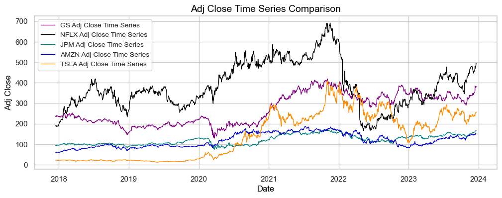

```python
stocks_to_plot = ['GS', 'NFLX', 'JPM', 'AMZN', 'TSLA']
compare_timeseries(data, stocks_to_plot, 'Adj Close')
```

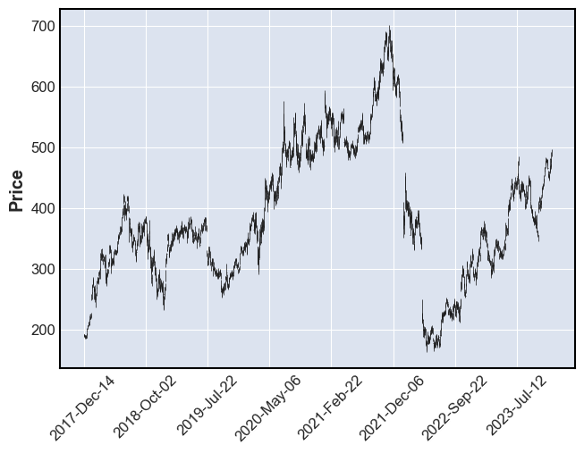

```python
mpf.plot(data['NFLX'])
```

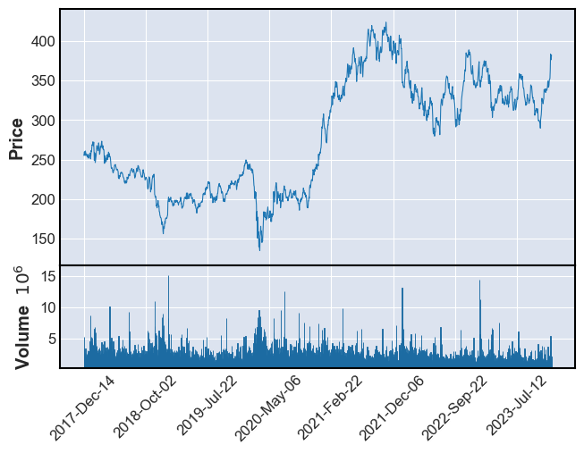

```python
mpf.plot(data['GS'], type='line', volume=True)
```

### Log returns

```python
def compare_timeseries_log_returns(data, stocks, variable):

    log_returns = {}
    for symbol in stocks:
        log_returns[symbol] = np.log(data[symbol][variable] / data[symbol][variable].shift(1))

    colors = ['teal', 'black', 'purple', 'teal', 'mediumblue', 'darkorange', 'red', 'gold']
    for i, symbol in enumerate(stocks):
        sns.set(style="whitegrid", rc={'figure.figsize': (12, 4)})
        sns.lineplot(data=log_returns[symbol], label=f'{symbol} Log Returns', color=colors[i], linewidth=0.7)
    plt.xlabel('Date', fontsize=12)
    plt.ylabel('Log Returns', fontsize=12)
    plt.title('Log Returns Comparison', fontsize=16)
    plt.legend(loc='upper left', fontsize=10)
    plt.tight_layout()
    plt.show()
```

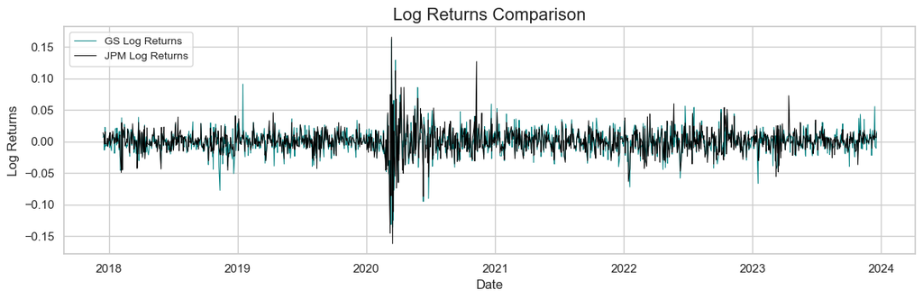

```python
stocks_to_plot = ['GS', 'JPM']
compare_timeseries_log_returns(data, stocks_to_plot, 'Adj Close')
```

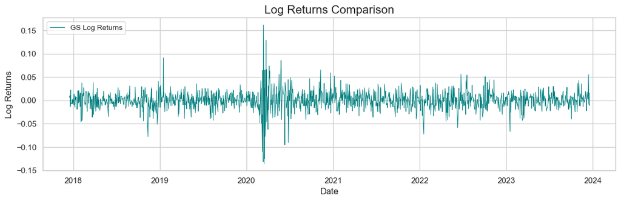

```python
stocks_to_plot = ['GS']
compare_timeseries_log_returns(data, stocks_to_plot, 'Adj Close')
```

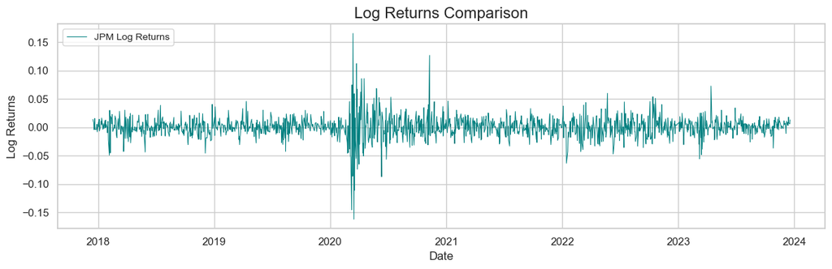

```python
stocks_to_plot = ['JPM']
compare_timeseries_log_returns(data, stocks_to_plot, 'Adj Close')
```